# Singapore Metabarcodes (Singkaryotes) - Eukaryotes

Daniel Vaulot, Adriana Lopes

29 11 2018

# 1 To do

## 1.1 Urgent

- Re-assign Mamiellophyceae with updated PR2
- Plot ratio of auto/total euks or auto/hetero

## 1.2 Other

# 2 Methodology

- For assignation with Wang assigner, only ASVs with bootstrap at super group level taked into account
- Metazoa and Fungi not taken into account
- Abundant" OTUs are more than 10% in at least one sample
- Some samples for which the quality of sequencing was bad have been removed (Caroline list)
- Samples have been normalized to the medium number of reads for the group considered (e.g. for all eukaryotes or for all photosynthetic eukaryotes)

# 3 Environmental data

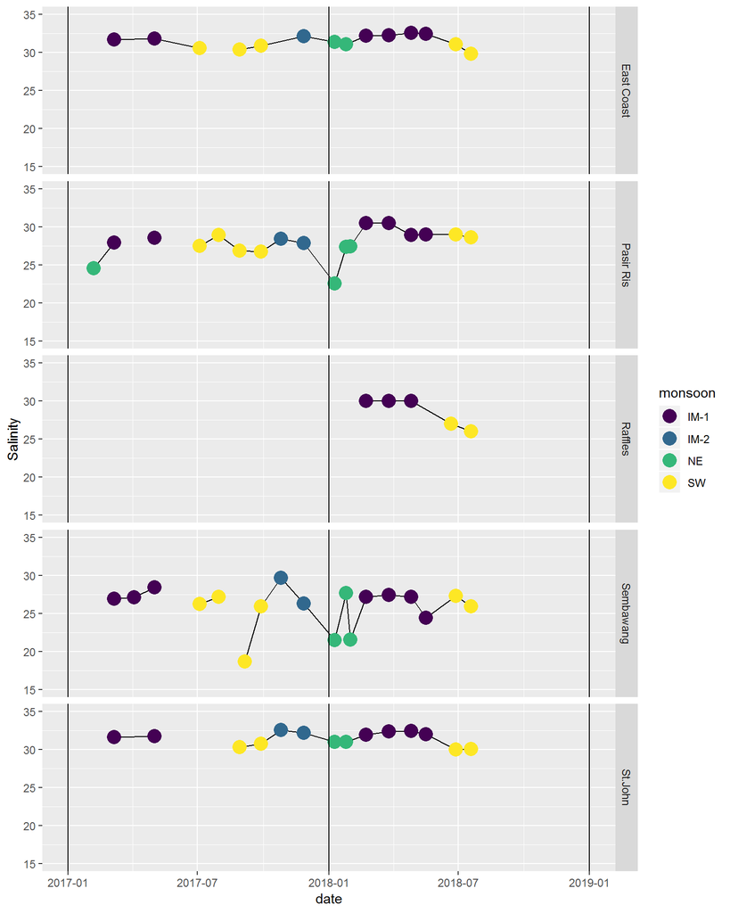

Figure 3.1: Salinity variation at the different stations with effect of monsoon

# 4 Basic statistics

- 663 ASVs of which 267 are autotrophs
- 81 samples

# 5 Taxonomic composition

- Dinoflagellates are dominating followed by diatoms (Figure 5.1)
- Among the key genera/species there are clear differences between Johor and Singapore (Raffles should merged with Singapore probably for this kind of comparison)
  - Dinos (Figure 5.7): *Gyrodinium fusiforme* (Johor), *Gyrodinium gutrula*; *Woloszeunskia halophila* (Johor), *Karlodinium veneficum* (Singapore)
  - Diatoms (Figure 5.8): Most diatoms are on the Johor side except for *Leptocylindrus*, *Chaetoceros* (endosymbiont), *Cyclotella* (Johor), *Carataulina* (Johor), *Thalassiosira*, *Shionodiscus*
  - Chlorophyta (Figure 5.5, 5.6, 5.4): *Nanochloris* (*Picochlorum*, mostly in Johor), *Micromonas* clade A.ABC.1-2 (M. commoda, mostly Singapore), *Micromonas* clade lagoons (in fact we call it warm now, mostly Singapore), *Ostreococcus* clade A (*lucimarinus*) and *tauri*
  - Crypto (Figure 5.3): *Geminigera* (Singapore)

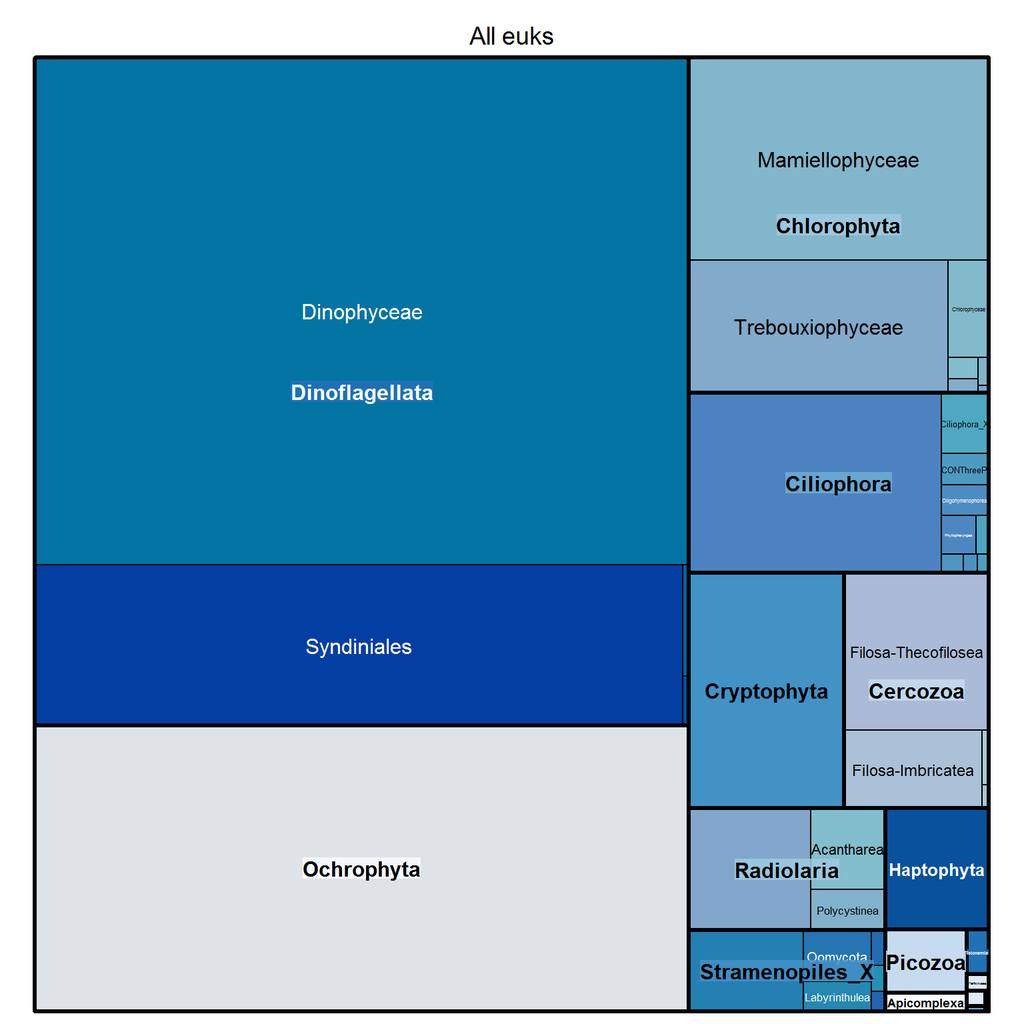

Figure 5.1: Overall euk composition

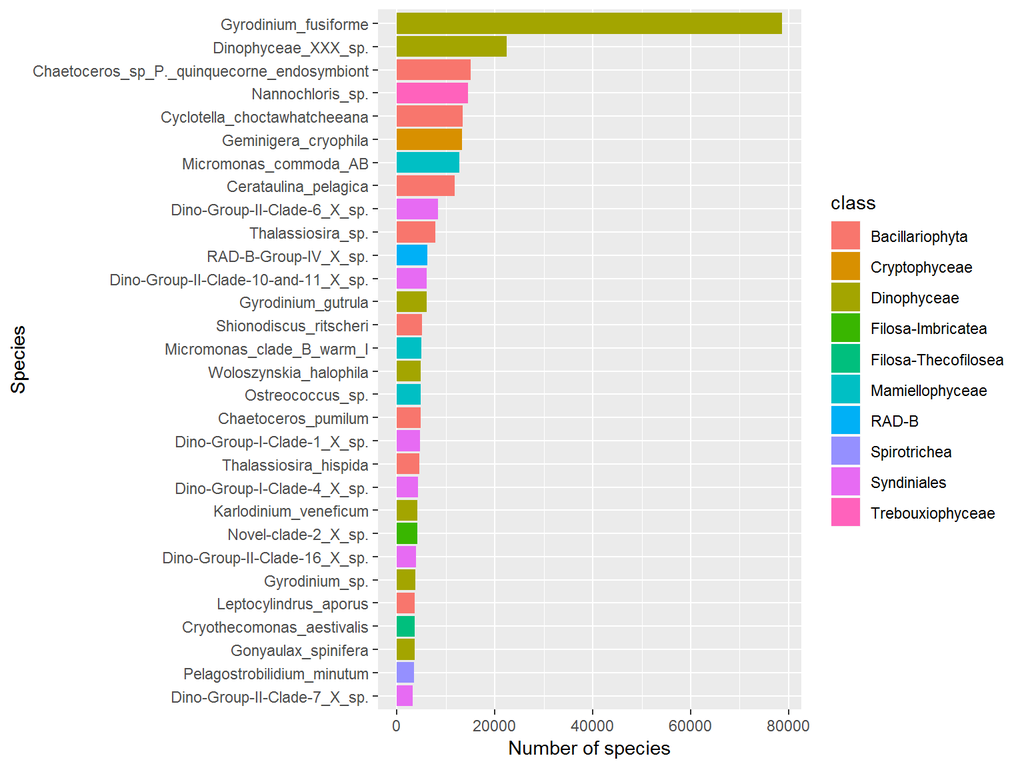

Figure 5.2: Major species

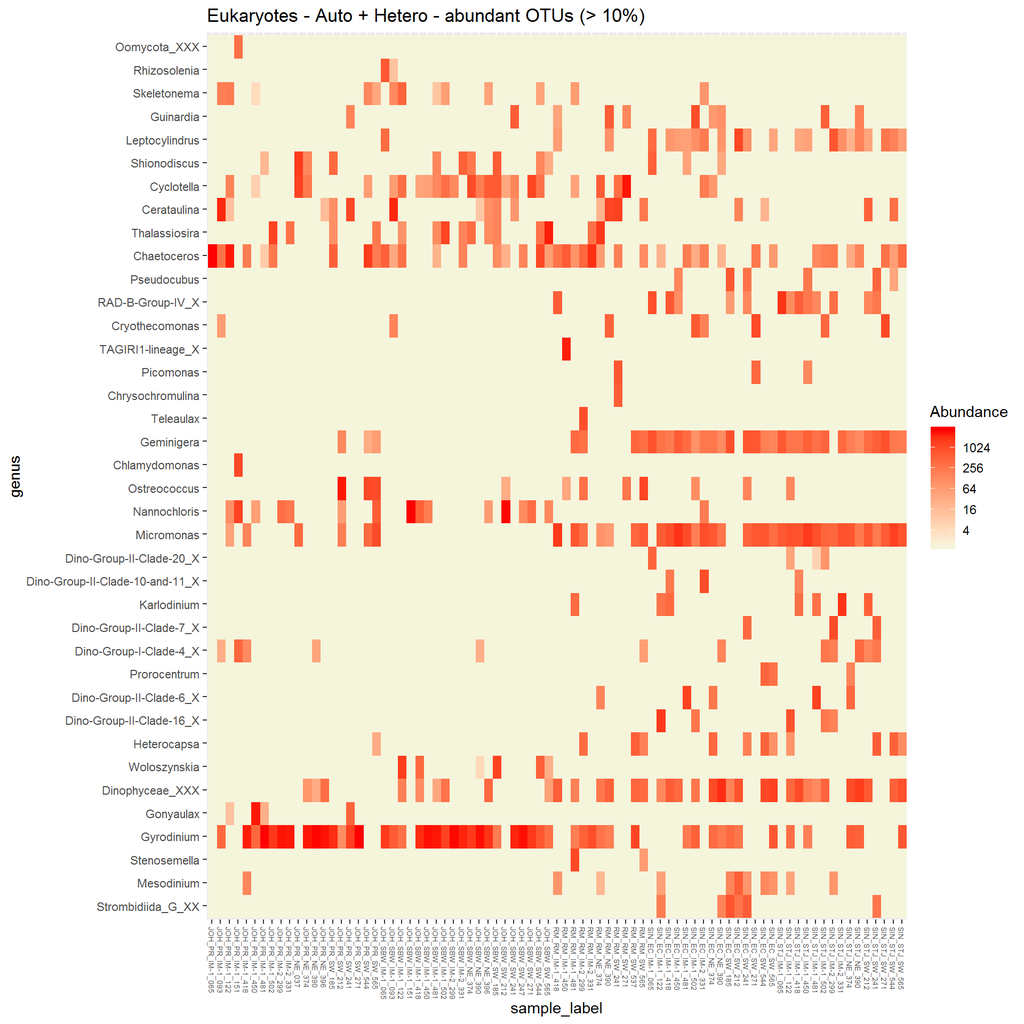

Figure 5.3: Heatmap for major Eukaryote genera

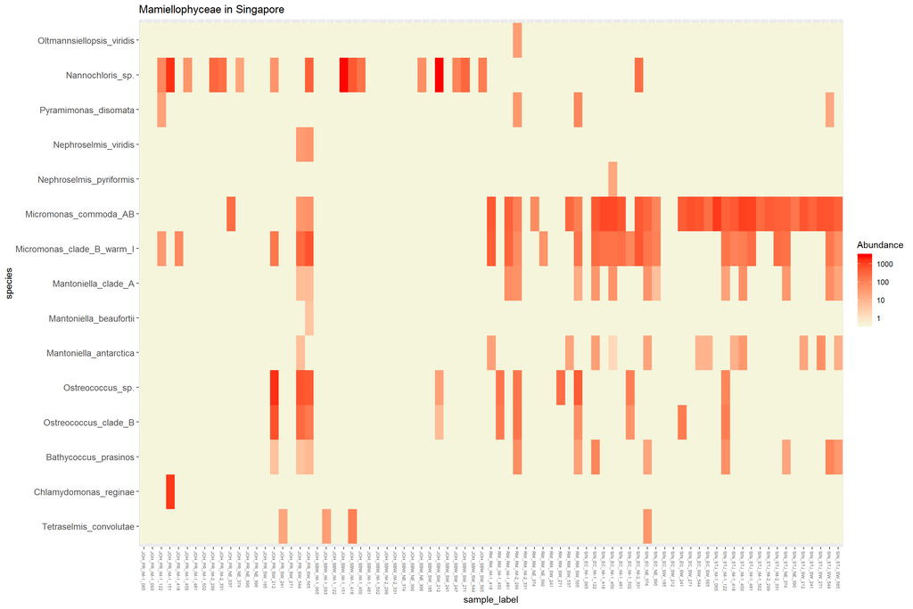

Figure 5.4: Heatmap for Chlorophyta species

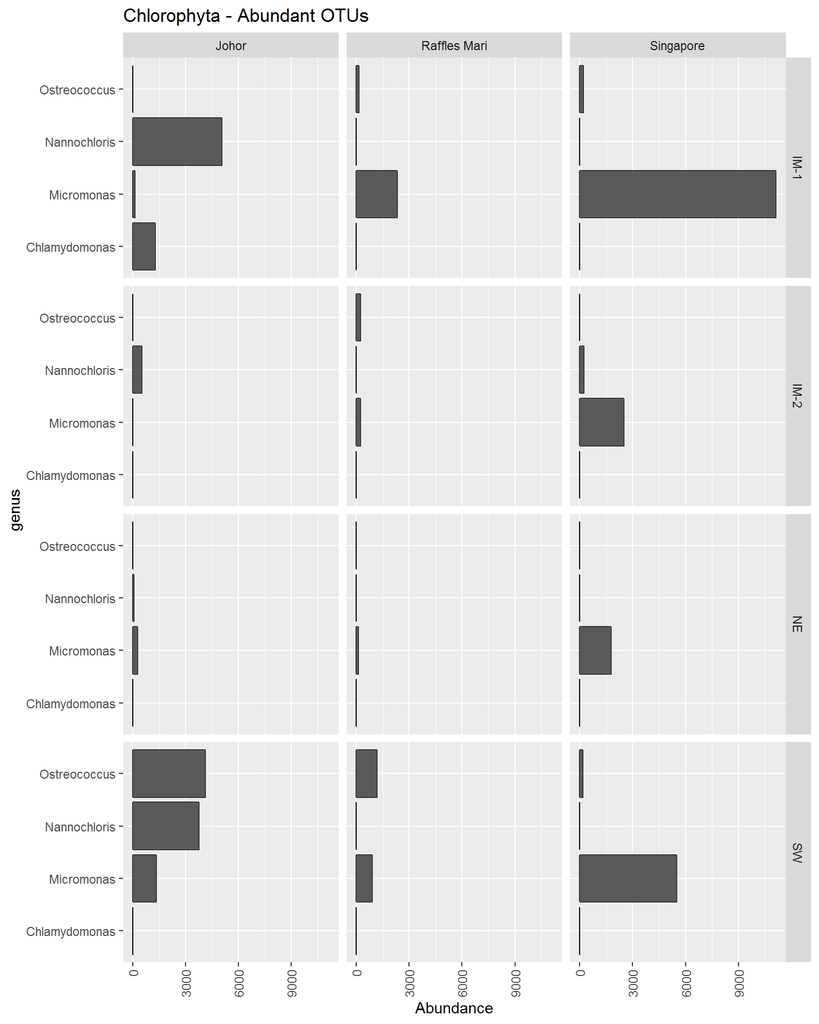

Figure 5.5: Localization of major Chlorophyta genera

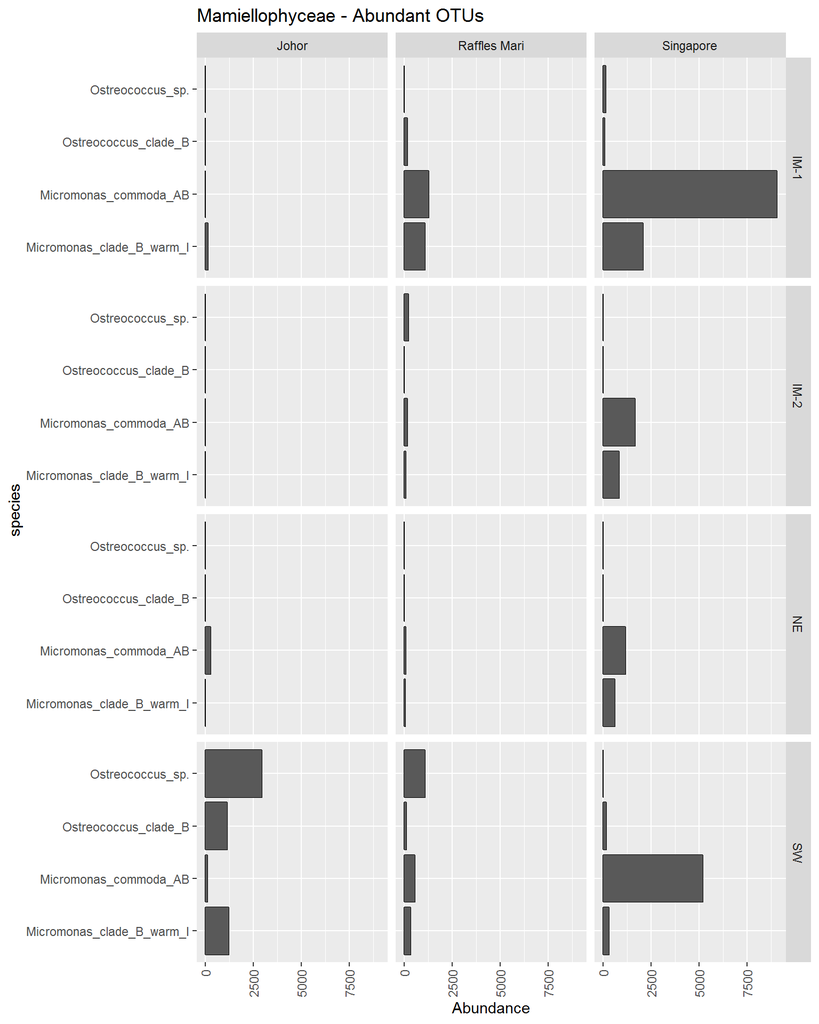

Figure 5.6: Localization of major Mamiellophyceae species

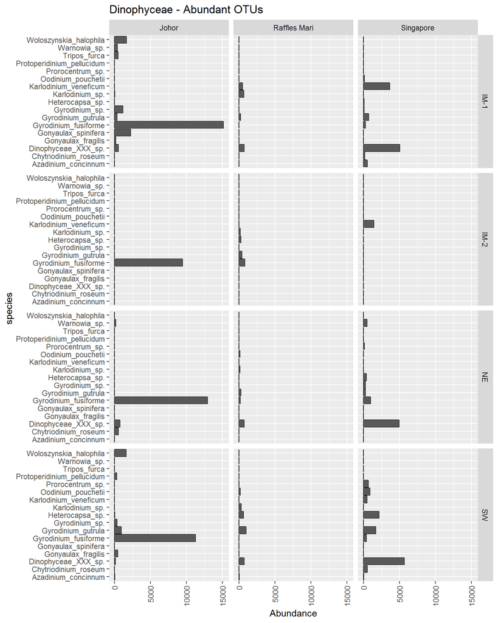

Figure 5.7: Localization of major Dinophyceae species

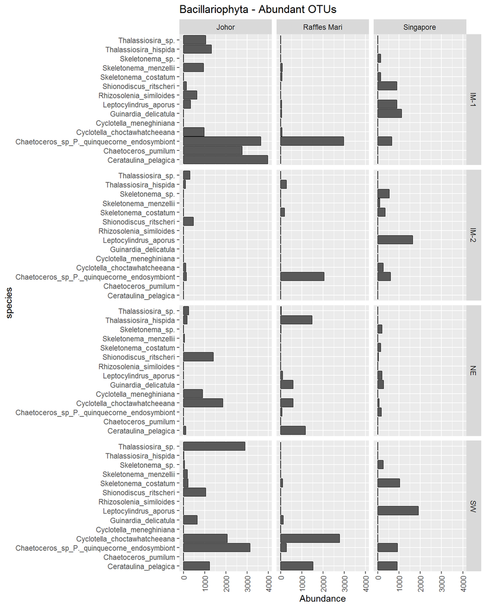

Figure 5.8: Localization of major diatoms species

# 6 Effect of different factors on eukaryote composition

- Radiolaria, Cryptophyta, Ciliophora, Cercozoa only found in Singapore strait and Raffles (Figure 6.1)
- Monsoon has less effect on the overall composition… (Figure 6.3)

Query: should we do just on the Photosynthetic eukaryotes or all eukaryotes ?

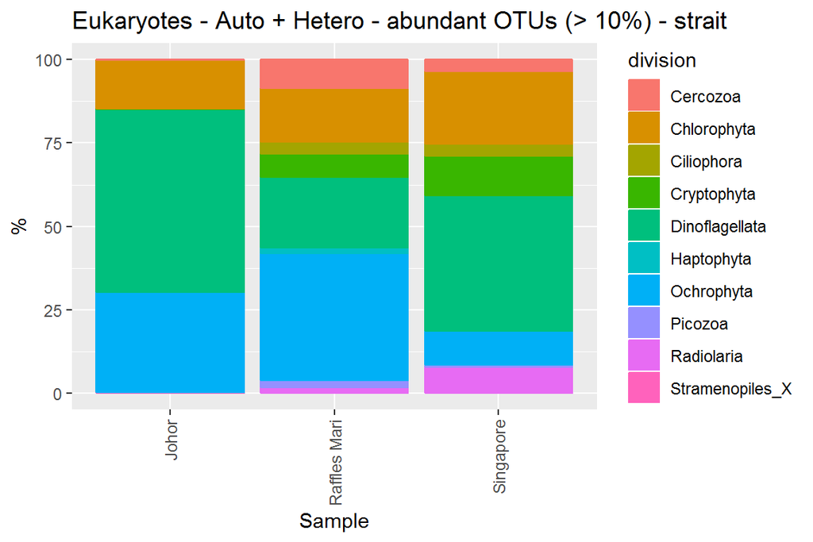

Figure 6.1: Effect of strait on overall eukaryote composition

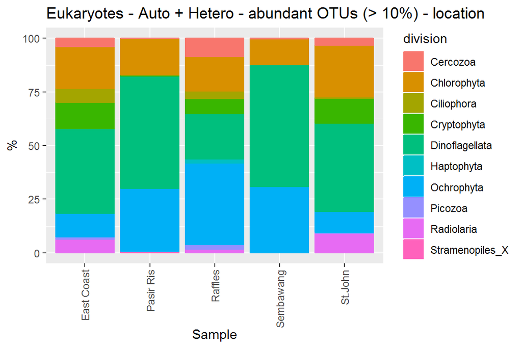

Figure 6.2: Effect of station on overall eukaryote composition

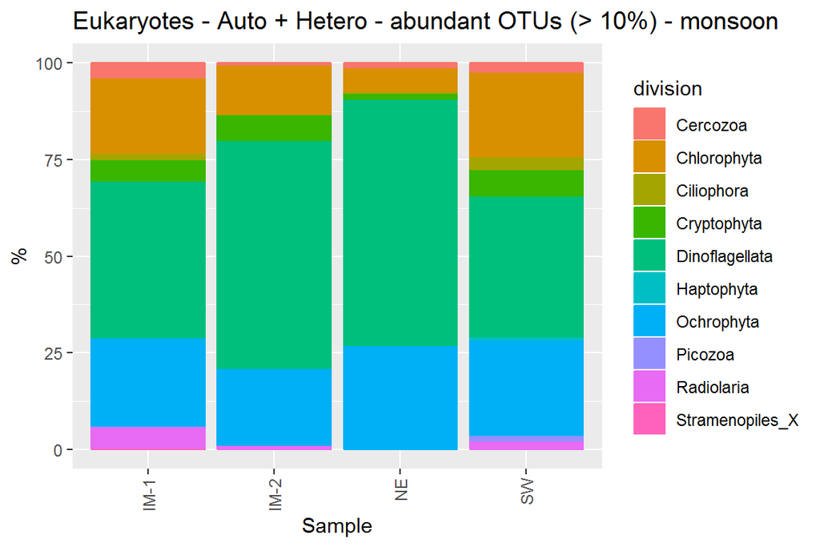

Figure 6.3: Effect of monsoon on overall eukaryote composition

# 7 NMDS

- The strait seems to be most discriminant factor (Figure 7.1).
- However it is interesting that for eukaryotes (Figure 7.2) Raffles Marina seems to be clustering with Singapore straight rather than Johor most of the time while for prokaryotes (Figure 7.1), Raffles is clearly in between. *Probably an interesting point to discuss.*

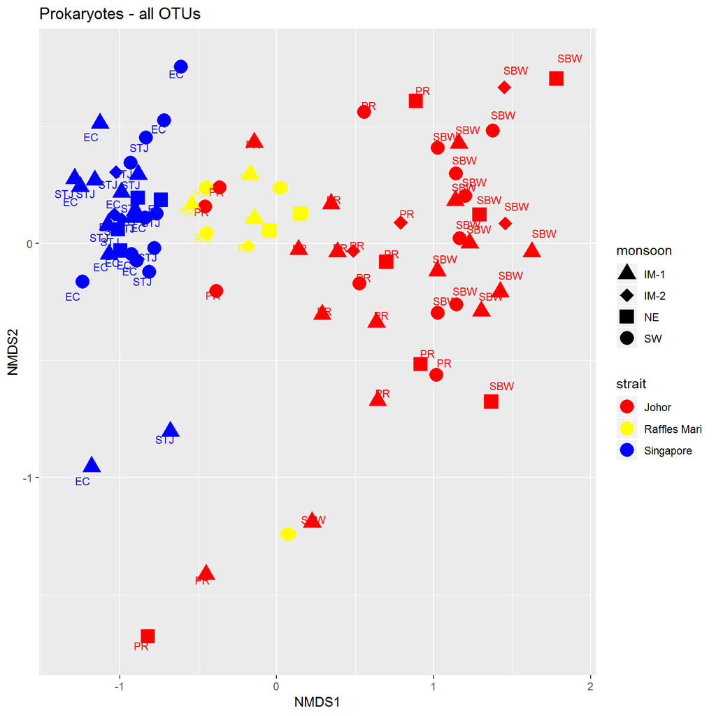

Figure 7.1: NMDS - Prokaryotes

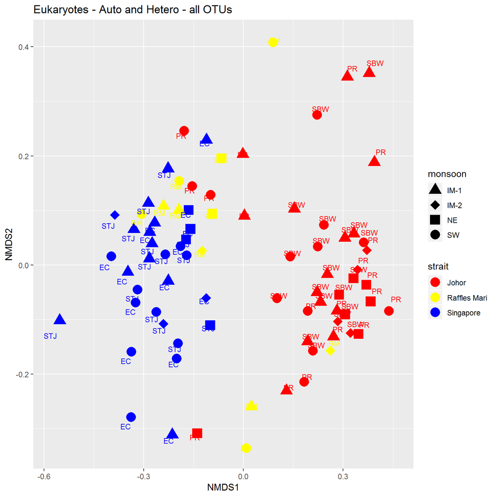

Figure 7.2: NMDS - All eukaryotes

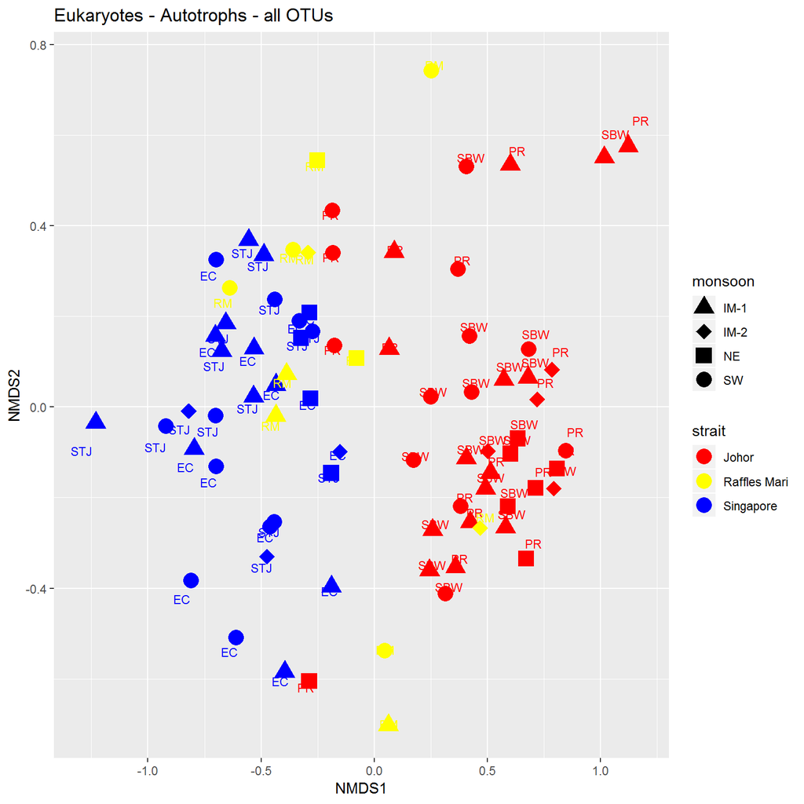

Figure 7.3: NMDS - Photosynthetic eukaryotes

# 8 Comparison with OSD

- OSD V4 while Singkaryotes amplicon is more upstream. There is no overlap between the two regions so for Mamiellophyceae the comparison is difficult with the new clades defined by Margot (e.g. clade E for *Ostreococcus*)

## 8.1 Mamiellophyceae

- Investigate in more details the Mamiellophyceae based on master alignement (clades). Check in particular whether we have Ostreo lucimarinus or Ostreo claude B

### 8.1.1 OSD

Species/clades in **bold** are found in both OSD and Singkaryotes

| Species Mamiello | % |
| --- | --- |
| **Micromonas commoda AB** | 36.33 |
| **Bathycoccus prasinos** | 10.20 |
| **Ostreococcus clade B** | 9.90 |
| **Micromonas clade B warm I** | 5.31 |
| **Micromonas clade B warm II** | 4.80 |
| Ostreococcus clade E | 3.62 |

### 8.1.2 Singkaryote data set

**Bathycoccus prasinos** **Micromonas commoda AB**  
**Micromonas clade B warm**  
**Ostreo clade B**  
Ostreo sp. -> This may correspond to Ostreo clade E

## 8.2 Ochrophyta

Seems coherent  
* **Singkaryote**, Diatoms (super dominant), Chrysophyceae, Raphidophyceae  
* **OSD**: Diatoms are also dominant follwoed by Chrysophyceae and Raphodophyceae

## 8.3 Haptophyta

Seems coherent  
* **Singkaryote**, Chrysochromulina, Emiliana, Haptolina, Phaeocystis  
* **OSD** : Chrysochromulina, Phaeocystis, Haptolina, Emiliana